# DATS 6101: Intro to Data Science - Mid Term Project

## Car color

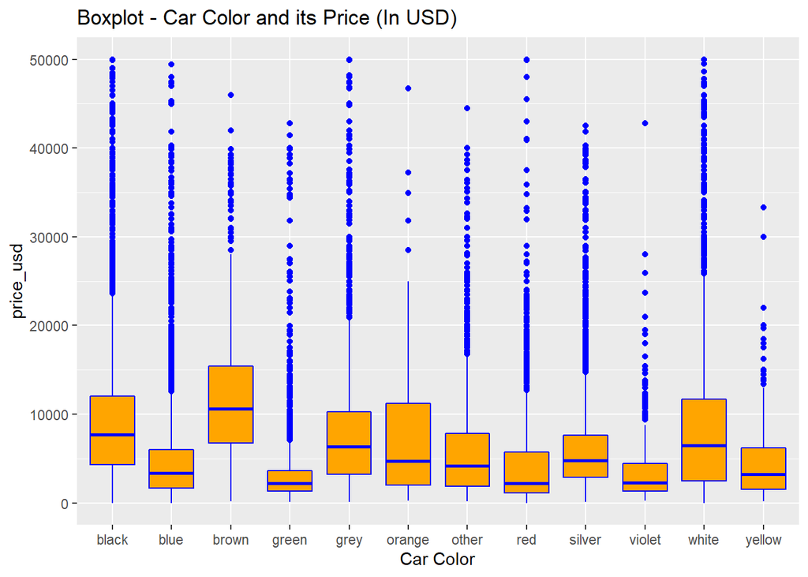

```r
plot1 <- ggplot(car_data, aes(x=color, y=price_usd)) +
  geom_boxplot(color="blue", fill="orange")+
  labs(x="Car Color",y="price_usd") + labs(title="Boxplot - Car Color and its Price (In USD)")
plot1
```

## has warranty feature

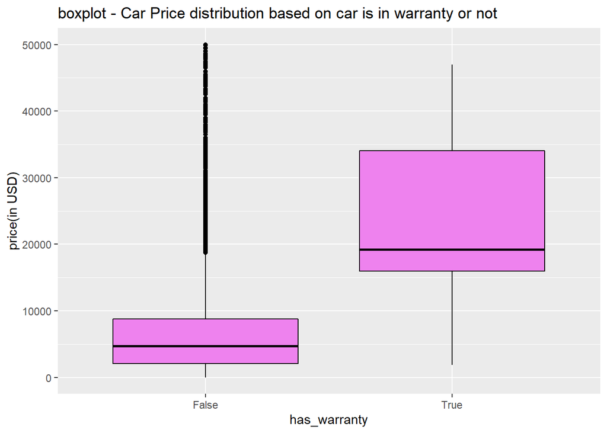

```r
plot_warranty <- ggplot(car_data, aes(x=has_warranty, y=price_usd)) +
  geom_boxplot(color="black", fill="violet")+
  labs(x="has_warranty",y="price(in USD)") + labs(title="boxplot - Car Price distribution based on car is in warranty or not")
plot_warranty
```

As we can see, cars which are in warranty have the better resell prices than the cars which are not covered under warranty. Also we can see so many outliers in ‘no warranty’ categories. That pool is belongs to the vintage cars where prices are high but the car is not in the warranty.

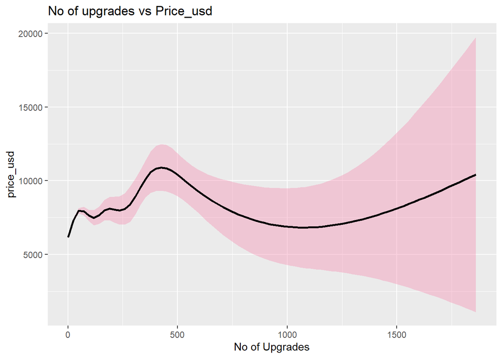

```r
plot_upgrade <- ggplot(car_data, aes(x=up_counter, y=price_usd)) +
  geom_smooth(color="black", fill="#F48FB1")+
  labs(x="No of Upgrades",y="price_usd") + labs(title="No of upgrades vs Price_usd")
plot_upgrade
```

## body Type

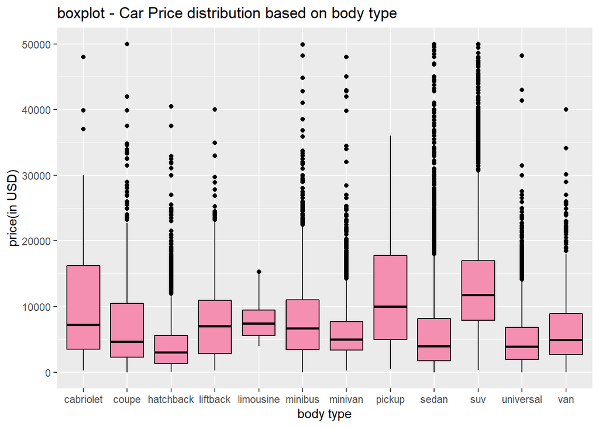

```r
plot_body <- ggplot(car_data, aes(x=body_type, y=price_usd)) +
  geom_boxplot(color="black", fill="#F48FB1")+
  labs(x="body type",y="price(in USD)") + labs(title="boxplot - Car Price distribution based on body type")
plot_body
```

#Number of photos

Creating buckets for number of photos feature

```r
Photo_bucket <- within(car_data, {
  Photo_bucket.cat <- NA # need to initialize variable
  Photo_bucket.cat[number_of_photos < 6] <- "0-5"
  Photo_bucket.cat[number_of_photos >= 6 & number_of_photos < 11] <- "6-10"
  Photo_bucket.cat[number_of_photos >= 11 & number_of_photos < 16] <- "11-15"
  Photo_bucket.cat[number_of_photos >= 16 & number_of_photos < 21] <- "16-20"
  Photo_bucket.cat[number_of_photos >= 21 & number_of_photos < 26] <- "21-25"
  Photo_bucket.cat[number_of_photos >= 26 & number_of_photos < 31] <- "26-30"
  Photo_bucket.cat[number_of_photos > 30] <- "more than 30"
   } )

#str(dat)


Photo_bucket$Photo_bucket.cat <- factor(Photo_bucket$Photo_bucket.cat, levels= c("0-5","6-10","11-15","16-20","21-25","26-30","more than 30"))
```

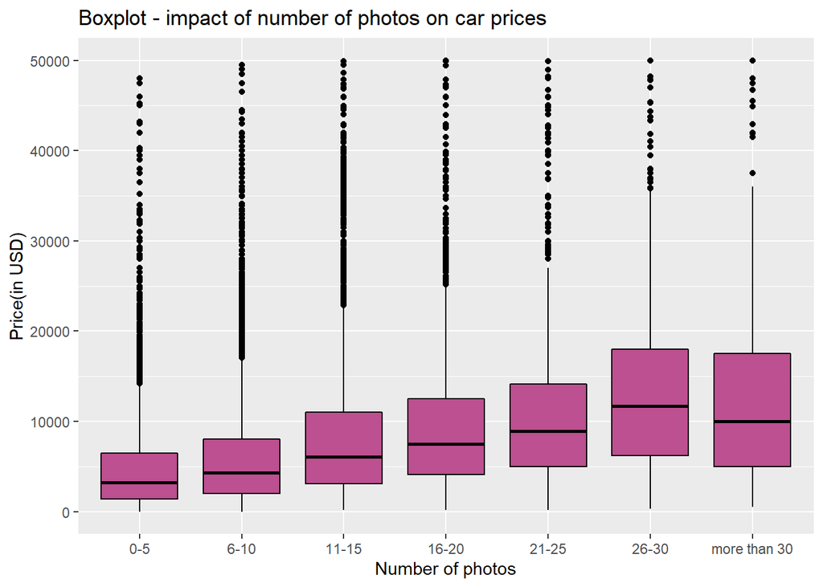

```r
ggplot(Photo_bucket, aes(y = price_usd , x = Photo_bucket.cat)) + geom_boxplot(color="black", fill="#bc5090") + labs(title = 'Boxplot - impact of number of photos on car prices') + labs(x = 'Number of photos', y = 'Price(in USD)')
```

## Drivetrain

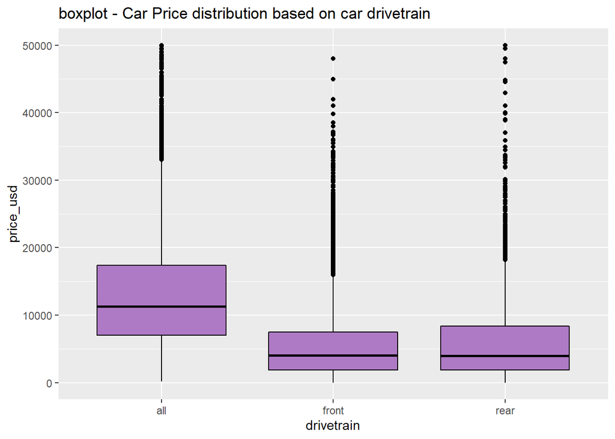

```r
plot_warranty <- ggplot(car_data, aes(x=drivetrain, y=price_usd)) +
  geom_boxplot(color="black", fill="#AF7AC5")+
  labs(x="drivetrain",y="price_usd") + labs(title="boxplot - Car Price distribution based on car drivetrain")
plot_warranty
```

Car prices are high in case of all wheel drive and for front and rear wheel drive, the median price range is almost same.

## Duration listed

relation of resale prices with duration listed on the catalog

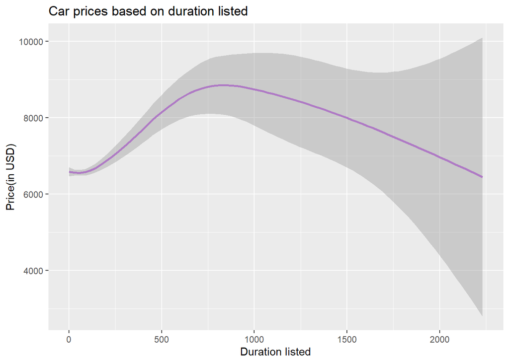

```r
ggplot(data = car_data, aes(x = duration_listed, y = price_usd)) +
    geom_smooth(color = '#AF7AC5') +
    labs(title = 'Car prices based on duration listed') + labs(x="Duration listed",y="Price(in USD)")
```